# Lab 4: Childcare Costs

- Show All Code
- Hide All Code
- View Source

Author

Sammy Paykel

Published

February 2, 2025

## The Data

In this lab we’re going look at the median weekly cost of childcare in California. A detailed description of the data can be found [here](https://github.com/rfordatascience/tidytuesday/blob/master/data/2023/2023-05-09/readme.md).

The data come to us from [TidyTuesday](https://github.com/rfordatascience/tidytuesday).

**0. Load the appropriate libraries and the data.**

```r
library(tidyverse)
```

```r
childcare_costs <- read_csv('https://raw.githubusercontent.com/rfordatascience/tidytuesday/master/data/2023/2023-05-09/childcare_costs.csv')

counties <- read_csv('https://raw.githubusercontent.com/rfordatascience/tidytuesday/master/data/2023/2023-05-09/counties.csv')

childcare_costs
counties
```

**1. Briefly describe the dataset (~ 4 sentences). What information does it contain?**

The childcare_costs table provides information on childcare prices across U.S. counties from 2008 to 2018. It includes details on the cost of childcare services based on provider type (such as home-based or center-based care) and the age group of children. The dataset will be useful to analyze regional cost variations and trends in childcare affordability over time. Additionally, there is another table called counties, which will mostly be used as reference against the childcare_costs table.

## California Childcare Costs

Let’s start by focusing only on California.

```r
ca_counties <- counties |> filter(state_name == "California")

ca_childcare <- childcare_costs |> inner_join(ca_counties, by = "county_fips_code")

nrow(ca_childcare)  # should be 638
```

**3. Using a function from the `forcats` package, complete the code below to create a new variable where each county is categorized into one of the [10 Census regions](https://census.ca.gov/regions/) in California. Use the Region description (from the plot), not the Region number.**  
*Hint: This is probably a good place to use ChatGPT to reduce on tedious work. But you do need to know how to prompt ChatGPT to make it useful!*

```r
ca_childcare <- ca_childcare |>
  mutate(county_name = str_remove(county_name, " County")) |>
  mutate(region = fct_recode(county_name,
    "San Francisco Bay Area" = "Alameda", "San Francisco Bay Area" = "Contra Costa", "San Francisco Bay Area" = "Marin", "San Francisco Bay Area" = "Napa",
    "San Francisco Bay Area" = "San Francisco", "San Francisco Bay Area" = "San Mateo", "San Francisco Bay Area" = "Santa Clara", "San Francisco Bay Area" = "Solano",
    "San Francisco Bay Area" = "Sonoma",

    "Orange County" = "Orange",

    "Los Angeles County" = "Los Angeles",

    "Northern San Joaquin Valley" = "San Joaquin", "Northern San Joaquin Valley" = "Stanislaus", "Northern San Joaquin Valley" = "Merced", "Northern San Joaquin Valley" = "Madera",
    "Northern San Joaquin Valley" = "Fresno", "Northern San Joaquin Valley" = "Kings", "Northern San Joaquin Valley" = "Tulare", "Northern San Joaquin Valley" = "Kern",

    "Central Coast" = "Santa Cruz", "Central Coast" = "Monterey", "Central Coast" = "San Luis Obispo", "Central Coast" = "Santa Barbara",

    "Inland Empire" = "San Bernardino", "Inland Empire" = "Riverside",

    "Superior California" = "Del Norte", "Superior California" = "Siskiyou", "Superior California" = "Modoc",
    "Northern Sacramento Valley" = "Shasta", "Northern Sacramento Valley" = "Tehama", "Northern Sacramento Valley" = "Glenn", "Northern Sacramento Valley" = "Butte",

    "Southern San Joaquin Valley" = "Sacramento", "Southern San Joaquin Valley" = "El Dorado", "Southern San Joaquin Valley" = "Placer",

    "San Diego - Imperial" = "San Diego",

    "North Coast" = "Humboldt", "North Coast" = "Lake"
  ))
```

**4. Let’s consider the median household income of each region, and how that income has changed over time. Create a table with ten rows, one for each region, and two columns, one for 2008 and one for 2018. The cells should contain the `median` of the median household income (expressed in 2018 dollars) of the `region` and the `study_year`. Arrange the rows by 2018 values.**

```r
ca_childcare_summary <- ca_childcare |>
  group_by(region, study_year) |>
  summarise(median_income = median(mhi_2018, na.rm = TRUE)) |>
  pivot_wider(names_from = study_year, values_from = median_income, names_prefix = "year_") |>
  arrange(desc(year_2018))

print(ca_childcare_summary)
```

[output not shown]

**5. Which California `region` had the lowest `median` full-time median weekly price for center-based childcare for infants in 2018? Does this `region` correspond to the `region` with the lowest `median` income in 2018 that you found in Q4?**  
*Hint: The code should give me the EXACT answer. This means having the code output the exact row(s) and variable(s) necessary for providing the solution.*

```r
# Find the region with the lowest median full-time weekly price for center-based childcare for infants in 2018:
lowest_childcare_price <- ca_childcare |>
  filter(study_year == 2018) |>
  group_by(region) |>
  summarise(lowest_price = min(mc_infant, na.rm = TRUE)) |>
  arrange(lowest_price) |>
  slice(1)

# Find the region with the lowest median income in 2018:
lowest_income_region <- ca_childcare_summary |>
  filter(!is.na(year_2018)) |>
  arrange(year_2018) |>
  slice(1)

# Display the lowest childcare price and corresponding region, and the lowest income region:
list(
  lowest_childcare_price = lowest_childcare_price,
  lowest_income_region = lowest_income_region
)
```

[output not shown]

**6. The following plot shows, for all ten regions, the change over time of the full-time median price for center-based childcare for infants, toddlers, and preschoolers. Recreate the plot. You do not have to replicate the exact colors or theme, but your plot should have the same content, including the order of the facets and legend, reader-friendly labels, axes breaks, and a loess smoother.**

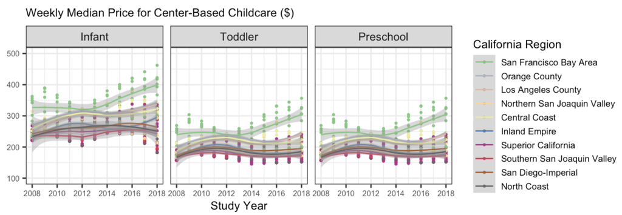

Plot to recreate

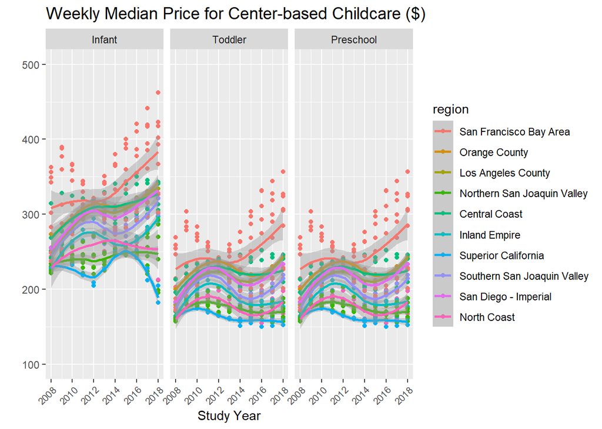

```r
ca_childcare %>%
  mutate(region = fct_relevel(ca_childcare$region,
                            c("San Francisco Bay Area",
                              "Orange County",
                              "Los Angeles County",
                              "Northern San Joaquin Valley",
                              "Central Coast",
                              "Inland Empire",
                              "Superior California",
                              "Southern San Joaquin Valley",
                              "San Diego - Imperial",
                              "North Coast"))) %>%

  filter(region %in% c("San Francisco Bay Area",
                              "Orange County",
                              "Los Angeles County",
                              "Northern San Joaquin Valley",
                              "Central Coast",
                              "Inland Empire",
                              "Superior California",
                              "Southern San Joaquin Valley",
                              "San Diego - Imperial",
                              "North Coast")) %>%

  select(study_year,
         region,
         mc_infant,
         mc_toddler,
         mc_preschool) %>%

  pivot_longer(cols = c(mc_infant,
                        mc_toddler,
                        mc_preschool),
               names_to = "child_age_group",
               values_to = "median_price") %>%

  mutate(child_age_group = factor(child_age_group,
                                  levels = c("mc_infant", "mc_toddler", "mc_preschool"),
                                  labels = c("Infant", "Toddler", "Preschool"))) %>%

  ggplot(aes(x = study_year,
             y = median_price,
             color = region)) +
  geom_point() +
  geom_smooth() +
  facet_wrap(~child_age_group) +
  scale_x_continuous(breaks = seq(2008, 2018, by = 2)) +
  scale_y_continuous(breaks = seq(100, 500, by = 100),
                     limits = c(100, 500)) +
  labs(x = "Study Year",
       y = " ",
       title = "Weekly Median Price for Center-based Childcare ($)") +
  theme(
    plot.title = element_text(size = 14),
    axis.text.x = element_text(angle = 45, hjust = 1, size = 8)
  )
```

## Median Household Income vs. Childcare Costs for Infants

**7. Create a scatterplot showing the relationship between median household income (expressed in 2018 dollars) and the full-time median weekly price charged for center-based childcare for an infant in California. Overlay a linear regression line (lm) to show the trend.**

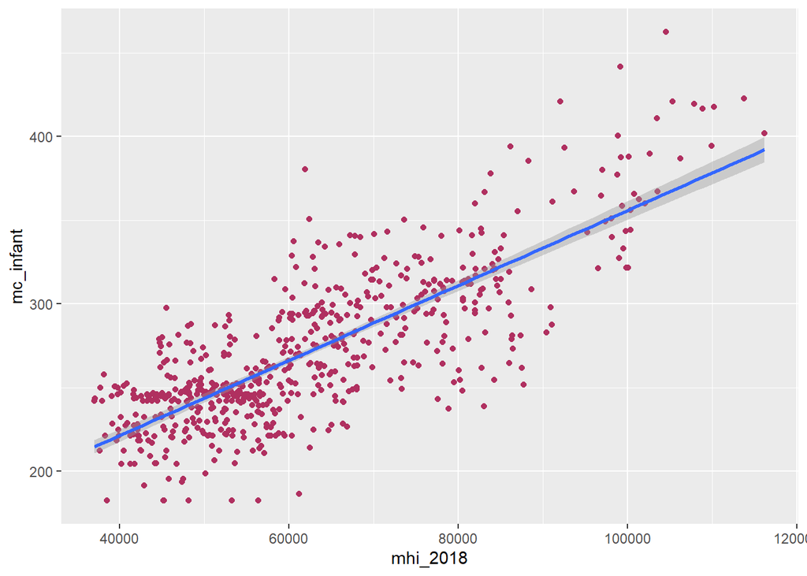

```r
scatter_data <- ca_childcare |>
  select(c("mhi_2018", "mc_infant")) |>
  ggplot(aes(x = mhi_2018, y = mc_infant)) +
  geom_point(color = "maroon") +
  geom_smooth(method="lm", formula= y ~ x)

print(scatter_data)
```

**8. Look up the documentation for `lm()` and fit a linear regression model to the relationship shown in your plot above.**

```r
# complete the code provided
linear_reg <- ca_childcare |>
  select(c("mhi_2018", "mc_infant"))
reg_mod1 <- lm(mc_infant ~ mhi_2018, linear_reg)
summary(reg_mod1)
```

[output not shown]

**9. Using the output from `summary()`, write out the estimated regression line (recall: $y = mx + b$).**

**10. Do you have evidence to conclude there is a relationship between the median household income and the median weekly cost of center-based childcare for infants in California? Cite values from your `summary()` output to support your claim!**

## Sources:

- https://www.datacamp.com/tutorial/linear-regression-R
- http://www.flutterbys.com.au/stats/downloads/slides/figure/factors.pdf
- https://rstudio.github.io/cheatsheets/html/data-visualization.html
- https://nyu-cdsc.github.io/learningr/assets/data-transformation.pdf
- https://towardsdatascience.com/understanding-linear-regression-output-in-r-7a9cbda948b3
- ChatGPT for that one question lol